# Predicting how well an excercise is performed

Mark M

19 September 2014

## Introduction

Data from accelerometers on the belt, forearm, arm, and dumbell of 6 participants performing weight lifting excercises was collected. The variable to predict has 1 of 5 possible class values:

- A - exactly according to the specification
- B - throwing the elbows to the front
- C - lifting the dumbbell only halfway
- D - lowering the dumbbell only halfway
- E - throwing the hips to the front

Class A corresponds to the correct specified execution of the exercise, while the other 4 classes correspond to common mistakes.

Read more: http://groupware.les.inf.puc-rio.br/har#weight_lifting_exercises#ixzz3DkZJOVkC

## Pre-processing

The following libraries are used:

```r
library(caret)
library(randomForest)
```

It is assumed that the training and test datasets have already been downloaded into a ‘data’ subdirectory.

```r
#download.file("https://d396qusza40orc.cloudfront.net/predmachlearn/pml-training.csv", "data/pml-training.csv", method="curl")
#download.file("https://d396qusza40orc.cloudfront.net/predmachlearn/pml-testing.csv", "data/pml-testing.csv", method="curl")
```

The training and test datasets are loaded as CSV files, substituting NA for missing values.

```r
training <- read.csv("data/pml-training.csv", na.strings=c("", "NA", "#DIV/0!"))
testing <- read.csv("data/pml-testing.csv", na.strings=c("", "NA", "#DIV/0!"))
```

Remove metadata such as username and time fields.

```r
training <- training[, -(1:7)]
testing <- testing[, -(1:7)]
```

Split the training data into train and cross-validation (test) sets.

```r
in.train <- createDataPartition(training$classe, p=0.6, list=F)
train <- training[in.train, ]
test <- training[-in.train, ]
```

The target variable (y) is the “classe” column.

```r
train.y <- train$classe
in.y <- grep("classe", colnames(train))
train <- train[, -in.y]
test.y <- test$classe
test <- test[, -in.y]
```

Omit “near zero variance” predictors.

```r
nzv <- nearZeroVar(train)
train <- train[, -nzv]
test <- test[, -nzv]
testing <- testing[, -nzv]
```

Omit columns with missing values.

```r
na.columns <- apply(train, 2, function (x) any(is.na(x)))
train <- train[, !na.columns]
test <- test[, !na.columns]
testing <- testing[, !na.columns]
```

Remove highly correlated columns.

```r
cor <- cor(train)
highlyCor <- findCorrelation(cor, cutoff=0.95)
train <- train[, -highlyCor]
test <- test[, -highlyCor]
testing <- testing[, -highlyCor]
```

## Exploratory Analysis

Feature plots of various combinations of variables were performed, such as the following. No discernible patterns or strong predictors were uncovered from visual analysis.

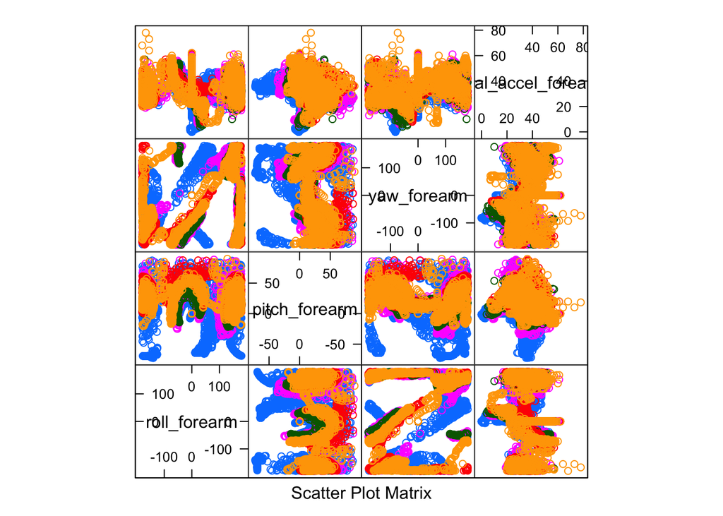

```r
featurePlot(x=train[, grep("forearm$", names(train))], y=train.y, plot="pairs")
```

## Prediction

After evaluating a number of algorithms, Random Forests was selected as the most useful.

A cross-validation test set was created using 40% of observations from the training file. Testing the model below against the cross-validation test set shows an accuracy 99.5%. The Kappa statistic, an alternative measure of error, is 99.3%. (The advantages of the Kappa statistic include that it attempts to correct for chance expected agreement, and is not affected by a few zero cell entries.)

```r
modFit <- randomForest(train, train.y)
confusionMatrix(predict(modFit, newdata=test), test.y)
```

```
## Confusion Matrix and Statistics
##
##           Reference
## Prediction    A    B    C    D    E
##          A 2226    2    0    0    0
##          B    5 1511    6    0    0
##          C    0    5 1360   17    0
##          D    0    0    2 1269    4
##          E    1    0    0    0 1438
##
## Overall Statistics
##
##                Accuracy : 0.995
##                  95% CI : (0.993, 0.996)
##     No Information Rate : 0.284
##     P-Value [Acc > NIR] : <2e-16
##
##                   Kappa : 0.993
##  Mcnemar's Test P-Value : NA
##
## Statistics by Class:
##
##                      Class: A Class: B Class: C Class: D Class: E
## Sensitivity             0.997    0.995    0.994    0.987    0.997
## Specificity             1.000    0.998    0.997    0.999    1.000
## Pos Pred Value          0.999    0.993    0.984    0.995    0.999
## Neg Pred Value          0.999    0.999    0.999    0.997    0.999
## Prevalence              0.284    0.193    0.174    0.164    0.184
## Detection Rate          0.284    0.193    0.173    0.162    0.183
## Detection Prevalence    0.284    0.194    0.176    0.163    0.183
## Balanced Accuracy       0.998    0.997    0.995    0.993    0.999
```

The top variables in order of importance are:

```r
vi <- varImp(modFit)
top.vars <- rownames(vi)[order(-vi)[1:10]]
top.vars
```

```
##  [1] "yaw_belt"          "magnet_dumbbell_z" "pitch_forearm"
##  [4] "pitch_belt"        "magnet_dumbbell_y" "roll_forearm"
##  [7] "magnet_belt_y"     "magnet_dumbbell_x" "magnet_belt_z"
## [10] "roll_dumbbell"
```